# Assignment 3: Reinforcement Learning Pipeline in Practice

*CS260R: Reinforcement Learning. Department of Computer Science at University of California, Los Angeles. Course Instructor: Professor Bolei ZHOU. Assignment author: Zhenghao PENG.*

## TODOs

You need to implement all TODOs in the python files. Then run all cells in this notebook and plot your results.

Note:

1. You can run the training in your terminal and selectively run the visualization and evaluation cells in this notebook.
2. You need to remove the "REFERENCE" in figures.
3. You don't need to exactly reproduce our results, but your implementation should show the similar progress in training.
4. We use multi-processing to enable asynchronous data sampling. Therefore in many places the tensors have shape `[num_steps, num_envs, num_feat]`. This means that `num_envs` environments are running concurrently and each of them samples a fragment of trajectory with length `num_steps`. There are totally `num_steps*num_envs` transitions are generated in each training iteration.
5. Each process can only have a single MetaDrive environment.
6. The jupyter notebook is used for tutorial and visualization. It is optional for you to use the notebook to call `train_ppo|td3.py` and `eval_ppo|td3.py`. But we expect to see figures, results and visualization in this notebook.

We are expecting the following figures, results and visualization:

1. TD3 in Pendulum-v1: learning curve (2.1)
2. TD3 in MetaDrive-Tut-Hard-v0: learning curve (2.2), evaluation result (2.3)
3. PPO in CartPole-v1: learning curve (3.1)
4. PPO in MetaDrive-Tut-Hard-v0: learning curve (3.2), evaluation result (3.3), visualization (3.4)

### File structure

You need to pay attention to the files below:

TD3:

- `core/td3_trainer.py` - File which can be directly run to train TD3. **Please implement TD3 here.**

PPO:

- `train_ppo.py` - Train scripts for PPO in CartPole-v0 and MetaDrive. **Please implement TODO in this file.**
- `core/ppo_trainer.py` - PPO algorithm. **Please implement `compute_action` and `compute_loss`.**
- `core/buffer.py` - Supporting data structure for PPO (GAE is implemented here). **Please implement `compute_returns` for PPO.**

Common:

- `assignment3.ipynb` - Useful jupyter notebook to walk you through the whole assignment. You need to plot figures and results here.
- `[train|eval]_[ppo|td3].py` - The entries to training and evaluation.

### Deliverables

1. The exported **PDF file** of the this notebook.
2. Compress all files in the `assignment3` folder and prepare a **ZIP file**. No `.rar` or other format is allowed.

You need to submit **both the ZIP file and the PDF file** to bruinlearn. The PDF file goes to gradescope tab and the ZIP file goes to the assignment tab.

### Colab supporting

Though we use multiple files to implement algorithms, we can still leverage Colab for free computing resources.

- Step 1: Create a folder in your Google Drive root named `cs260r`
- Step 2: Upload the files in `assignment3` folder such as `train_ppo.py` and the folder `core` to the newly created `cs260r` folder in your Google Drive.
- Step 3: Run the last cell in Demo 1 (pay attention to the code we mount the colab to your google drive).

## Demo 1: Setup dependencies

```python
!pip install torch

# Install MetaDrive, a lightweight driving simulator
!pip install git+https://github.com/metadriverse/metadrive

# Test whether MetaDrive is properly installed. No error means the test is passed.
!python -m metadrive.examples.profile_metadrive --num-steps 100

!pip install pandas scipy seaborn tabulate pyyaml
```

```
  Cloning https://github.com/metadriverse/metadrive to c:\users\admin\appdata\local\temp\pip-req-build-f37g8v5g
  Resolved https://github.com/metadriverse/metadrive to commit 13befc8e6ddc5f3ffe907073007fb3ea187d87db
  Preparing metadata (setup.py): started
  Preparing metadata (setup.py): finished with status 'done'
```

```
  Running command git clone --filter=blob:none --quiet https://github.com/metadriverse/metadrive 'C:\Users\Admin\AppData\Local\Temp\pip-req-build-f37g8v5g'
```

```
Start to profile the efficiency of MetaDrive with 1000 maps and ~4 vehicles!
Finish 100/100 simulation steps. Time elapse: 0.3701. Average FPS: 737.1464, Average number of vehicles: 3.0000
Total Time Elapse: 0.370, average FPS: 737.146, average number of vehicles: 3.000.
```

```
[INFO] Environment: MetaDriveEnv
[INFO] MetaDrive version: 0.4.3
[INFO] Sensors: [lidar: Lidar(), side_detector: SideDetector(), lane_line_detector: LaneLineDetector()]
[INFO] Render Mode: none
[INFO] Horizon (Max steps per agent): None
[INFO] Assets version: 0.4.3
[INFO] Known Pipes: wglGraphicsPipe
[INFO] Start Scenario Index: 1010, Num Scenarios : 1000
[INFO] Episode ended! Scenario Index: 1900 Reason: out_of_road.
```

```
Downloading tabulate-0.9.0-py3-none-any.whl (35 kB)
```

```python
import os

try:
    from google.colab import drive
    drive.mount('/content/gdrive')

    DRIVE_PATH = '/content/gdrive/My Drive/cs260r'  # No need for backslash
    if not os.path.exists(DRIVE_PATH):
        !mkdir -p "$DRIVE_PATH"  # Ensure the folder exists

    # Create a symlink to avoid issues with spaces in 'My Drive'
    SYM_PATH = '/content/cs260r'
    if not os.path.exists(SYM_PATH):
        !ln -s "$DRIVE_PATH" "$SYM_PATH"

    running_in_colab = True

    # We already mounted in our google drive.
    # Enter the foler where you put files in:
    %cd '/content/cs260r'

except ModuleNotFoundError:
    running_in_colab = False
    print("I guess you are running locally. If you get this message in Colab, something is wrong.")

print("\nCurrent working directory:")
%pwd

print("\nWhat files are there:")
%ls
```

```
I guess you are running locally. If you get this message in Colab, something is wrong.

Current working directory:

What files are there:
 Volume in drive C is Windows
 Volume Serial Number is 9034-6F82

 Directory of C:\Users\Admin\Documents\cs260r-assignment-2025winter\assignment3

02/23/2025  05:18 PM    <DIR>          .
02/23/2025  05:18 PM    <DIR>          ..
02/17/2025  10:14 PM               176 .style.yapf
02/17/2025  10:14 PM                 0 __init__.py
02/22/2025  05:56 PM    <DIR>          __pycache__
02/23/2025  05:18 PM         3,449,771 assignment3.html
02/22/2025  08:10 PM         3,541,647 assignment3.ipynb
02/22/2025  07:17 PM           131,329 cartpole-ppo.png
02/22/2025  07:09 PM    <DIR>          CartPole-v1
02/22/2025  05:00 PM    <DIR>          core
02/17/2025  10:14 PM             1,988 eval_ppo.py
02/17/2025  10:14 PM             2,230 eval_td3.py
02/17/2025  10:14 PM               678 format.sh
02/22/2025  08:03 PM           121,948 metadrive-hard-ppo.png
02/22/2025  05:55 PM           111,325 metadrive-hard-td3.png
02/22/2025  07:18 PM    <DIR>          MetaDrive-Tut-Hard-v0
02/22/2025  05:27 PM           107,888 pendulum-td3.png
02/22/2025  05:14 PM    <DIR>          Pendulum-v1
02/17/2025  10:14 PM               343 README.md
02/17/2025  10:14 PM             7,224 train_ppo.py
02/17/2025  10:17 PM             6,802 train_td3.py
02/17/2025  10:14 PM             7,722 vis.py
              15 File(s)      7,491,071 bytes
               7 Dir(s)  83,119,853,568 bytes free
```

## Demo 2: Train a TD3 agent

Spinning Up tutorial provides great explaination on TD3 algorithm: https://spinningup.openai.com/en/latest/algorithms/td3.html

Please implement all TODOs in `core/td3_trainer.py` and `train_td3.py`.

### Demo 2.1: Train TD3 agent in Pendulum-v1

```python
!python train_td3.py \
--env-id Pendulum-v1 \
--log-dir Pendulum-v1 \
--max-steps 50000 \
--start-steps 1000 \
--lr 1e-3
```

```
c:\Users\Admin\Documents\cs260r-assignment-2025winter\assignment3\core
```

```
 ===== TD3 Training Step 1199 =====:
  actor_loss: 8.540311813354492
  critic_loss: 0.6517338156700134
  current_q1: -8.764493942260742
  current_q2: -8.759138107299805
  episode_reward: -1216.4010217830717
  frame_per_second: 528
  log_dir: Pendulum-v1
  reward: -6.311416149139404
  target_q: -8.78995132446289
  total_episodes: 6
  total_steps: 1199
  total_time: 2.267979383468628

Trainer is saved at <Pendulum-v1\td3>. Progress is saved at <Pendulum-v1\td3\progress.csv>.

 ===== TD3 Training Step 2199 =====:
  actor_loss: 22.673095703125
  critic_loss: 2.937506675720215
  current_q1: -23.019750595092773
  current_q2: -23.036638259887695
  episode_reward: -1383.6132996025501
  frame_per_second: 203
  log_dir: Pendulum-v1
  reward: -6.915778636932373
  target_q: -22.957294464111328
  total_episodes: 11
  total_steps: 2199
  total_time: 10.809183597564697


 ===== TD3 Training Step 3199 =====:
  actor_loss: 37.60356140136719
  critic_loss: 12.47491455078125
  current_q1: -37.45732116699219
  current_q2: -37.50157928466797
  episode_reward: -1408.8564774363197
  frame_per_second: 165
  log_dir: Pendulum-v1
  reward: -6.8067522048950195
```

[output cut: 704 more lines]

```
 ===== TD3 Training Step 49199 =====:
  actor_loss: 39.15369415283203
  critic_loss: 4.222097873687744
  current_q1: -40.068214416503906
  current_q2: -40.03590393066406
  episode_reward: -154.31558266532323
  frame_per_second: 117
  log_dir: Pendulum-v1
  reward: -1.4963083267211914
  target_q: -39.948760986328125
  total_episodes: 246
  total_steps: 49199
  total_time: 419.9734902381897

Trainer is saved at <Pendulum-v1\td3>. Progress is saved at <Pendulum-v1\td3\progress.csv>.
```

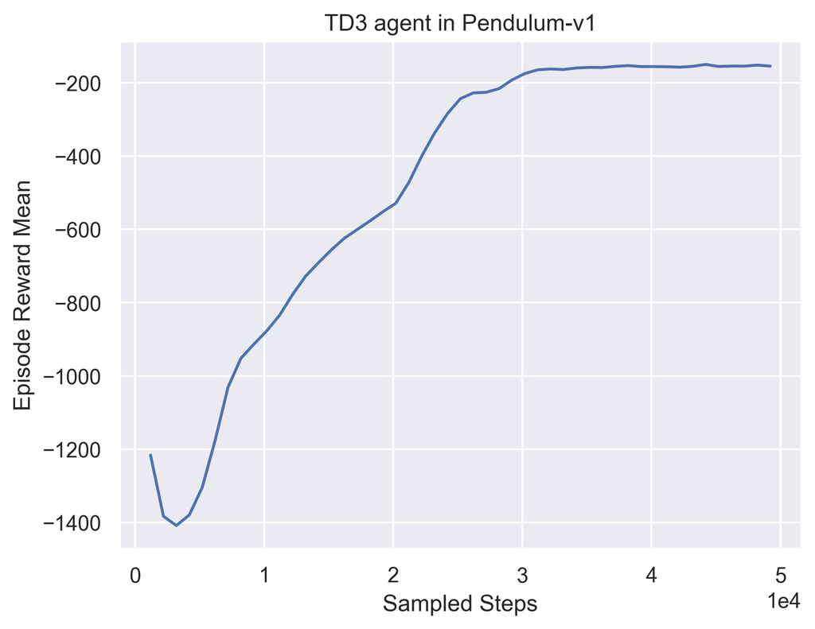

```python
import pandas as pd
import matplotlib.pyplot as plt
import seaborn as sns

progress = pd.read_csv("Pendulum-v1/td3/progress.csv")
plt.figure(dpi=300)
sns.set("notebook", "darkgrid")
ax = sns.lineplot(
    data=progress,
    x="total_steps",
    y="episode_reward"
)
ax.set_title("TD3 agent in Pendulum-v1")
ax.set_ylabel("Episode Reward Mean")
ax.set_xlabel("Sampled Steps")

# TODO: You should remove this line in your code.
# ax.annotate("REFERENCE", (0, -500), size=50, alpha=0.05)

ax.ticklabel_format(style='sci', scilimits=(0,0), axis='x')

plt.savefig('pendulum-td3.png', format='png', dpi=300, bbox_inches="tight")
```

### Demo 2.2: Train TD3 agent in MetaDrive-Tut-Hard-v0

```python
!python train_td3.py \
--env-id MetaDrive-Tut-Hard-v0 \
--log-dir MetaDrive-Tut-Hard-v0 \
--max-steps 100_000
```

```
c:\Users\Admin\Documents\cs260r-assignment-2025winter\assignment3\core
```

[output not shown]

[output cut: 117 more lines]

```














[INFO] Episode ended! Scenario Index: 1008 Reason: crash vehicle
```

```
Successfully registered MetaDrive environments:  ['MetaDrive-Tut-Easy-v0', 'MetaDrive-Tut-Hard-v0', 'MetaDrive-Tut-1Env-v0', 'MetaDrive-Tut-5Env-v0', 'MetaDrive-Tut-10Env-v0', 'MetaDrive-Tut-20Env-v0', 'MetaDrive-Tut-50Env-v0', 'MetaDrive-Tut-100Env-v0', 'MetaDrive-Tut-Test-v0']

 ===== TD3 Training Step 1999 =====:
  actor_loss: .nan
  critic_loss: .nan
  episode_reward: 8.018591272652802
  frame_per_second: 280
  log_dir: MetaDrive-Tut-Hard-v0
  success_rate: 0.0
  target_q: .nan
  total_episodes: 2
  total_steps: 1999
  total_time: 7.121610164642334

Trainer is saved at <MetaDrive-Tut-Hard-v0\td3>. Progress is saved at <MetaDrive-Tut-Hard-v0\td3\progress.csv>.

 ===== TD3 Training Step 2999 =====:
  actor_loss: .nan
  critic_loss: .nan
  episode_reward: 8.125269971453509
  frame_per_second: 301
  log_dir: MetaDrive-Tut-Hard-v0
  success_rate: 0.0
  target_q: .nan
  total_episodes: 3
  total_steps: 2999
  total_time: 9.952973127365112


 ===== TD3 Training Step 3885 =====:
  actor_loss: .nan
  critic_loss: .nan
  episode_reward: 7.154890265726485
  frame_per_second: 304
  log_dir: MetaDrive-Tut-Hard-v0
  success_rate: 0.0
  target_q: .nan
  total_episodes: 4
  total_steps: 3885
  total_time: 12.753015041351318
```

[output cut: 1553 more lines]

```
  actor_loss: -47.642127990722656
  critic_loss: 22.595001220703125
  current_q1: 47.55455017089844
  current_q2: 47.83530044555664
  episode_reward: 328.41449387680535
  frame_per_second: 60
  log_dir: MetaDrive-Tut-Hard-v0
  reward: 0.7198482155799866
  success_rate: 0.7
  target_q: 47.18674850463867
  total_episodes: 495
  total_steps: 99385
  total_time: 1636.787963628769

Trainer is saved at <MetaDrive-Tut-Hard-v0\td3>. Progress is saved at <MetaDrive-Tut-Hard-v0\td3\progress.csv>.
```

```
The log contains these keys:  Index(['Unnamed: 0', 'log_dir', 'frame_per_second', 'episode_reward',
       'total_steps', 'total_episodes', 'total_time', 'target_q', 'actor_loss',
       'critic_loss', 'success_rate', 'current_q1', 'current_q2', 'reward'],
      dtype='object')
```

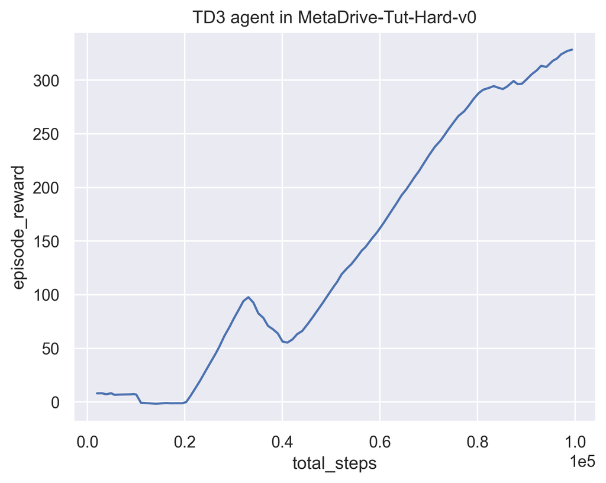

```python
import pandas as pd
import matplotlib.pyplot as plt
import seaborn as sns

progress = pd.read_csv("MetaDrive-Tut-Hard-v0/td3/progress.csv")
print("The log contains these keys: ", progress.keys())
plt.figure(dpi=300)
sns.set("notebook", "darkgrid")
ax = sns.lineplot(
    data=progress,
    x="total_steps",
    y="episode_reward"
)
ax.set_title("TD3 agent in MetaDrive-Tut-Hard-v0")

ax.ticklabel_format(style='sci', scilimits=(0,0), axis='x')

# TODO: You should remove this line in your code.
# ax.annotate("REFERENCE", (0, 200), size=50, alpha=0.05)

plt.savefig('metadrive-hard-td3.png', format='png', dpi=300, bbox_inches="tight")
```

### Demo 2.3: Evaluate TD3 in MetaDrive

```python
!python eval_td3.py \
--env-id="MetaDrive-Tut-Hard-v0" \
--log-dir="MetaDrive-Tut-Hard-v0/td3"
```

```
c:\Users\Admin\Documents\cs260r-assignment-2025winter\assignment3\core
c:\Users\Admin\Documents\cs260r-assignment-2025winter\assignment3\core
Successfully registered MetaDrive environments:  ['MetaDrive-Tut-Easy-v0', 'MetaDrive-Tut-Hard-v0', 'MetaDrive-Tut-1Env-v0', 'MetaDrive-Tut-5Env-v0', 'MetaDrive-Tut-10Env-v0', 'MetaDrive-Tut-20Env-v0', 'MetaDrive-Tut-50Env-v0', 'MetaDrive-Tut-100Env-v0', 'MetaDrive-Tut-Test-v0']
Successfully registered MetaDrive environments:  ['MetaDrive-Tut-Easy-v0', 'MetaDrive-Tut-Hard-v0', 'MetaDrive-Tut-1Env-v0', 'MetaDrive-Tut-5Env-v0', 'MetaDrive-Tut-10Env-v0', 'MetaDrive-Tut-20Env-v0', 'MetaDrive-Tut-50Env-v0', 'MetaDrive-Tut-100Env-v0', 'MetaDrive-Tut-Test-v0']
c:\Users\Admin\Documents\cs260r-assignment-2025winter\assignment3\core
c:\Users\Admin\Documents\cs260r-assignment-2025winter\assignment3\core
c:\Users\Admin\Documents\cs260r-assignment-2025winter\assignment3\core
c:\Users\Admin\Documents\cs260r-assignment-2025winter\assignment3\core
c:\Users\Admin\Documents\cs260r-assignment-2025winter\assignment3\core
c:\Users\Admin\Documents\cs260r-assignment-2025winter\assignment3\core
c:\Users\Admin\Documents\cs260r-assignment-2025winter\assignment3\core
c:\Users\Admin\Documents\cs260r-assignment-2025winter\assignment3\core
c:\Users\Admin\Documents\cs260r-assignment-2025winter\assignment3\core
c:\Users\Admin\Documents\cs260r-assignment-2025winter\assignment3\core
c:\Users\Admin\Documents\cs260r-assignment-2025winter\assignment3\core
c:\Users\Admin\Documents\cs260r-assignment-2025winter\assignment3\core
c:\Users\Admin\Documents\cs260r-assignment-2025winter\assignment3\core
c:\Users\Admin\Documents\cs260r-assignment-2025winter\assignment3\core
c:\Users\Admin\Documents\cs260r-assignment-2025winter\assignment3\core
c:\Users\Admin\Documents\cs260r-assignment-2025winter\assignment3\core
c:\Users\Admin\Documents\cs260r-assignment-2025winter\assignment3\core
c:\Users\Admin\Documents\cs260r-assignment-2025winter\assignment3\core
c:\Users\Admin\Documents\cs260r-assignment-2025winter\assignment3\core
c:\Users\Admin\Documents\cs260r-assignment-2025winter\assignment3\core
Successfully registered MetaDrive environments:  ['MetaDrive-Tut-Easy-v0', 'MetaDrive-Tut-Hard-v0', 'MetaDrive-Tut-1Env-v0', 'MetaDrive-Tut-5Env-v0', 'MetaDrive-Tut-10Env-v0', 'MetaDrive-Tut-20Env-v0', 'MetaDrive-Tut-50Env-v0', 'MetaDrive-Tut-100Env-v0', 'MetaDrive-Tut-Test-v0']
Successfully registered MetaDrive environments:  ['MetaDrive-Tut-Easy-v0', 'MetaDrive-Tut-Hard-v0', 'MetaDrive-Tut-1Env-v0', 'MetaDrive-Tut-5Env-v0', 'MetaDrive-Tut-10Env-v0', 'MetaDrive-Tut-20Env-v0', 'MetaDrive-Tut-50Env-v0', 'MetaDrive-Tut-100Env-v0', 'MetaDrive-Tut-Test-v0']
Successfully registered MetaDrive environments:  ['MetaDrive-Tut-Easy-v0', 'MetaDrive-Tut-Hard-v0', 'MetaDrive-Tut-1Env-v0', 'MetaDrive-Tut-5Env-v0', 'MetaDrive-Tut-10Env-v0', 'MetaDrive-Tut-20Env-v0', 'MetaDrive-Tut-50Env-v0', 'MetaDrive-Tut-100Env-v0', 'MetaDrive-Tut-Test-v0']
Successfully registered MetaDrive environments:  ['MetaDrive-Tut-Easy-v0', 'MetaDrive-Tut-Hard-v0', 'MetaDrive-Tut-1Env-v0', 'MetaDrive-Tut-5Env-v0', 'MetaDrive-Tut-10Env-v0', 'MetaDrive-Tut-20Env-v0', 'MetaDrive-Tut-50Env-v0', 'MetaDrive-Tut-100Env-v0', 'MetaDrive-Tut-Test-v0']
Successfully registered MetaDrive environments:  ['MetaDrive-Tut-Easy-v0', 'MetaDrive-Tut-Hard-v0', 'MetaDrive-Tut-1Env-v0', 'MetaDrive-Tut-5Env-v0', 'MetaDrive-Tut-10Env-v0', 'MetaDrive-Tut-20Env-v0', 'MetaDrive-Tut-50Env-v0', 'MetaDrive-Tut-100Env-v0', 'MetaDrive-Tut-Test-v0']
Successfully registered MetaDrive environments:  ['MetaDrive-Tut-Easy-v0', 'MetaDrive-Tut-Hard-v0', 'MetaDrive-Tut-1Env-v0', 'MetaDrive-Tut-5Env-v0', 'MetaDrive-Tut-10Env-v0', 'MetaDrive-Tut-20Env-v0', 'MetaDrive-Tut-50Env-v0', 'MetaDrive-Tut-100Env-v0', 'MetaDrive-Tut-Test-v0']
Successfully registered MetaDrive environments:  ['MetaDrive-Tut-Easy-v0', 'MetaDrive-Tut-Hard-v0', 'MetaDrive-Tut-1Env-v0', 'MetaDrive-Tut-5Env-v0', 'MetaDrive-Tut-10Env-v0', 'MetaDrive-Tut-20Env-v0', 'MetaDrive-Tut-50Env-v0', 'MetaDrive-Tut-100Env-v0', 'MetaDrive-Tut-Test-v0']
Successfully registered MetaDrive environments:  ['MetaDrive-Tut-Easy-v0', 'MetaDrive-Tut-Hard-v0', 'MetaDrive-Tut-1Env-v0', 'MetaDrive-Tut-5Env-v0', 'MetaDrive-Tut-10Env-v0', 'MetaDrive-Tut-20Env-v0', 'MetaDrive-Tut-50Env-v0', 'MetaDrive-Tut-100Env-v0', 'MetaDrive-Tut-Test-v0']
Successfully registered MetaDrive environments:  ['MetaDrive-Tut-Easy-v0', 'MetaDrive-Tut-Hard-v0', 'MetaDrive-Tut-1Env-v0', 'MetaDrive-Tut-5Env-v0', 'MetaDrive-Tut-10Env-v0', 'MetaDrive-Tut-20Env-v0', 'MetaDrive-Tut-50Env-v0', 'MetaDrive-Tut-100Env-v0', 'MetaDrive-Tut-Test-v0']
Successfully registered MetaDrive environments:  ['MetaDrive-Tut-Easy-v0', 'MetaDrive-Tut-Hard-v0', 'MetaDrive-Tut-1Env-v0', 'MetaDrive-Tut-5Env-v0', 'MetaDrive-Tut-10Env-v0', 'MetaDrive-Tut-20Env-v0', 'MetaDrive-Tut-50Env-v0', 'MetaDrive-Tut-100Env-v0', 'MetaDrive-Tut-Test-v0']
Finished 10/50 episodes. Average episode reward: 249.111
Finished 20/50 episodes. Average episode reward: 286.470
Finished 30/50 episodes. Average episode reward: 297.915
Finished 40/50 episodes. Average episode reward: 302.430
Finished 50/50 episodes. Average episode reward: 294.562
The average return after running TD3 agent for 50 episodes in MetaDrive-Tut-Hard-v0 environment: 294.5623916406736.
Result is saved at: MetaDrive-Tut-Hard-v0/td3/eval_results.csv
```

[output not shown]

[output cut: 108 more lines]

```
[INFO] Episode ended! Scenario Index: 1011 Reason: arrive_dest.
[INFO] Episode ended! Scenario Index: 1019 Reason: arrive_dest.
[INFO] Episode ended! Scenario Index: 1019 Reason: arrive_dest.
[INFO] Episode ended! Scenario Index: 1010 Reason: arrive_dest.
[INFO] Episode ended! Scenario Index: 1009 Reason: crash vehicle
[INFO] Episode ended! Scenario Index: 1002 Reason: crash vehicle
[INFO] Episode ended! Scenario Index: 1010 Reason: arrive_dest.
[INFO] Episode ended! Scenario Index: 1016 Reason: out_of_road.
[INFO] Episode ended! Scenario Index: 1018 Reason: out_of_road.
[INFO] Episode ended! Scenario Index: 1004 Reason: arrive_dest.
[INFO] Episode ended! Scenario Index: 1014 Reason: arrive_dest.
[INFO] Episode ended! Scenario Index: 1016 Reason: out_of_road.
[INFO] Episode ended! Scenario Index: 1016 Reason: out_of_road.
[INFO] Episode ended! Scenario Index: 1000 Reason: arrive_dest.
[INFO] Episode ended! Scenario Index: 1008 Reason: arrive_dest.
```

```python
import pandas as pd
import matplotlib.pyplot as plt
import seaborn as sns

td3_eval = pd.read_csv("MetaDrive-Tut-Hard-v0/td3/eval_results.csv")
print("TD3 agent average reward: {}".format(td3_eval.rewards.mean()))
```

```
TD3 agent average reward: 294.5623916406736
```

## Demo 3: Train a PPO agent

You need to finish `core/ppo_trainer.py`, `core/buffer.py` and `train_ppo.py`.

Here we use GAE [1] (Generalized Advantage Estimation) to estimate the advantage. This technique is implemented in `PPORolloutStorage.compute_returns` in `core/buffer.py`. Concretely, we estimate the advantage of current state $t$ via:

$$\delta_t = r_t + \gamma V(s_{t+1}) - V(s_t)$$

$$A^{GAE}_t = \sum_{l=0}^{\infty} (\gamma \lambda) ^ l \delta_{t+l}$$

wherein $V$ is the state value function, $\lambda$ is a hyper-parameter defined in `PPOConfig["gae_lambda"]`.

You can find that when $\lambda = 0$, the GAE estimates advantage in an one-step TD manner. When $\lambda = 1$, the GAE reduces to Monte Carlo Estimation of the state value. Therefore by varying the $\lambda$, we can adjust the trade-off between the accuracy of the estimation, namely the bias, and the variance of the advantage.

[1]: Schulman, John , et al. "High-Dimensional Continuous Control Using Generalized Advantage Estimation." (2015).

### Demo 3.1 Train and draw the learning curve of PPO in CartPole

```python
!python train_ppo.py \
--env-id CartPole-v1 \
--log-dir CartPole-v1 \
--num-envs 10 \
--max-steps 300000
```

```
c:\Users\Admin\Documents\cs260r-assignment-2025winter\assignment3\core
Start training!
c:\Users\Admin\Documents\cs260r-assignment-2025winter\assignment3\core
c:\Users\Admin\Documents\cs260r-assignment-2025winter\assignment3\core
c:\Users\Admin\Documents\cs260r-assignment-2025winter\assignment3\core
c:\Users\Admin\Documents\cs260r-assignment-2025winter\assignment3\core
c:\Users\Admin\Documents\cs260r-assignment-2025winter\assignment3\core
c:\Users\Admin\Documents\cs260r-assignment-2025winter\assignment3\core
c:\Users\Admin\Documents\cs260r-assignment-2025winter\assignment3\core
c:\Users\Admin\Documents\cs260r-assignment-2025winter\assignment3\core
c:\Users\Admin\Documents\cs260r-assignment-2025winter\assignment3\core
c:\Users\Admin\Documents\cs260r-assignment-2025winter\assignment3\core

 ===== ppo Training Iteration 0 =====:
  adv_mean: 8.544449806213379
  entropy: 0.6854138829769232
  episode_reward: 21.66
  frame_per_second: 1102
  grad_norm: 38.449898421458705
  iteration: 0
  log_dir: c:\Users\Admin\Documents\cs260r-assignment-2025winter\assignment3\CartPole-v1\ppo
  policy_loss: -0.016986302443397924
  ratio: 1.0010018738416524
  total_episodes: 884
  total_loss: 59.98056534987229
  total_steps: 20000
  total_time: 18.144805192947388
  value_loss: 59.99755155123197

Trainer is saved at <c:\Users\Admin\Documents\cs260r-assignment-2025winter\assignment3\CartPole-v1\ppo\checkpoint-iter0.pkl>. Progress is saved at <c:\Users\Admin\Documents\cs260r-assignment-2025winter\assignment3\CartPole-v1\ppo\progress.csv>.

 ===== ppo Training Iteration 1 =====:
  adv_mean: 7.805471897125244
  entropy: 0.6582230188907721
  episode_reward: 36.73
  frame_per_second: 1243
  grad_norm: 64.93233408805652
  iteration: 1
  log_dir: c:\Users\Admin\Documents\cs260r-assignment-2025winter\assignment3\CartPole-v1\ppo
  policy_loss: -0.017280317433118725
```

[output cut: 230 more lines]

```
 ===== ppo Training Iteration 15 =====:
  adv_mean: 0.0024518310092389584
  entropy: 0.4711626118574387
  episode_reward: 499.83
  frame_per_second: 1499
  grad_norm: 70.17717073513911
  iteration: 15
  log_dir: c:\Users\Admin\Documents\cs260r-assignment-2025winter\assignment3\CartPole-v1\ppo
  policy_loss: -0.001102644138229199
  ratio: 0.9994311347985879
  total_episodes: 2624
  total_loss: 112.06761387556027
  total_steps: 320000
  total_time: 213.4462695121765
  value_loss: 112.06871644044534
```

```
320000it [03:30, 1615.41it/s]
320000it [03:30, 1520.42it/s]
```

[figure not shown]

```python
import pandas as pd
import matplotlib.pyplot as plt
import seaborn as sns

ppo_progress = pd.read_csv("CartPole-v1/ppo/progress.csv")
plt.figure(dpi=300)
sns.set("notebook", "darkgrid")
ax = sns.lineplot(
    data=ppo_progress,
    x="total_steps",
    y="episode_reward"
)
ax.set_title("PPO agent in CartPole-v1")
ax.set_ylabel("Episode Reward Mean")
ax.set_xlabel("Sampled Steps")

# You should remove this line in your code:
# ax.annotate("REFERENCE", (ax.get_xlim()[1] / 10, ax.get_ylim()[1]*6/10), size=50, alpha=0.05)

ax.ticklabel_format(style='sci', scilimits=(0,0), axis='x')

plt.savefig('cartpole-ppo.png', format='png', dpi=300, bbox_inches="tight")
```

### Demo 3.2: Train and play with the PPO agent in MetaDrive Hard Env.

```python
!python train_ppo.py \
  --env-id MetaDrive-Tut-Hard-v0 \
  --log-dir MetaDrive-Tut-Hard-v0 \
  --num-envs 10 \
  --max-steps 1_000_000
```

```
c:\Users\Admin\Documents\cs260r-assignment-2025winter\assignment3\core
```

[output not shown]

[output cut: 6610 more lines]

```
[INFO] Episode ended! Scenario Index: 1002 Reason: out_of_road.
[INFO] Episode ended! Scenario Index: 1006 Reason: crash vehicle
[INFO] Episode ended! Scenario Index: 1015 Reason: crash vehicle
[INFO] Episode ended! Scenario Index: 1008 Reason: crash vehicle
[INFO] Episode ended! Scenario Index: 1013 Reason: crash vehicle
[INFO] Episode ended! Scenario Index: 1005 Reason: out_of_road.
[INFO] Episode ended! Scenario Index: 1010 Reason: out_of_road.
[INFO] Episode ended! Scenario Index: 1014 Reason: out_of_road.
[INFO] Episode ended! Scenario Index: 1013 Reason: out_of_road.
[INFO] Episode ended! Scenario Index: 1015 Reason: out_of_road.
[INFO] Episode ended! Scenario Index: 1017 Reason: out_of_road.
[INFO] Episode ended! Scenario Index: 1000 Reason: crash vehicle

1020000it [39:50, 414.03it/s]
1020000it [39:50, 426.65it/s]
```

[output not shown]

[output cut: 891 more lines]

```
  episode_reward: 134.00954214556938
  frame_per_second: 425
  grad_norm: 2056.128746854342
  iteration: 50
  log_dir: c:\Users\Admin\Documents\cs260r-assignment-2025winter\assignment3\MetaDrive-Tut-Hard-v0\ppo
  policy_loss: 0.0023981278678641103
  ratio: 1.0000996676010963
  success_rate: 0.0
  total_episodes: 6548
  total_loss: 97.1063854559874
  total_steps: 1020000
  total_time: 2394.862555503845
  value_loss: 97.10398743458283

Trainer is saved at <c:\Users\Admin\Documents\cs260r-assignment-2025winter\assignment3\MetaDrive-Tut-Hard-v0\ppo\checkpoint-iter50.pkl>. Progress is saved at <c:\Users\Admin\Documents\cs260r-assignment-2025winter\assignment3\MetaDrive-Tut-Hard-v0\ppo\progress.csv>.
```

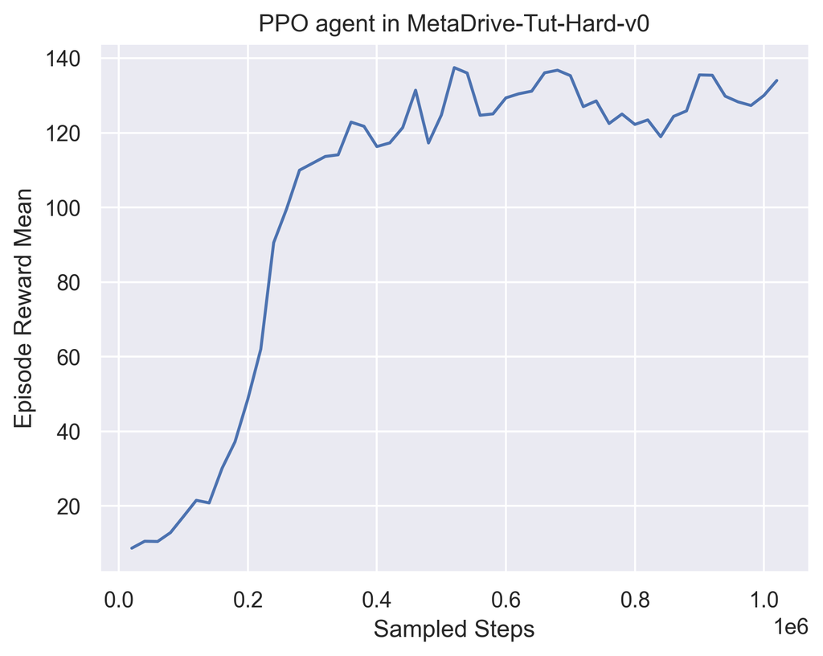

```python
import pandas as pd
import matplotlib.pyplot as plt
import seaborn as sns

ppo_progress = pd.read_csv("MetaDrive-Tut-Hard-v0/ppo/progress.csv")
plt.figure(dpi=300)
sns.set("notebook", "darkgrid")
ax = sns.lineplot(
    data=ppo_progress,
    x="total_steps",
    y="episode_reward"
)
ax.set_title("PPO agent in MetaDrive-Tut-Hard-v0")
ax.set_ylabel("Episode Reward Mean")
ax.set_xlabel("Sampled Steps")

ax.ticklabel_format(style='sci', scilimits=(0,0), axis='x')

# TODO: Remove this line
# ax.annotate("REFERENCE", (0, ax.get_ylim()[1]*6/10), size=50, alpha=0.05)

plt.savefig('metadrive-hard-ppo.png', format='png', dpi=300, bbox_inches="tight")
```

### Demo 3.3: Evaluate PPO in MetaDrive

```python
!python eval_ppo.py \
  --env-id="MetaDrive-Tut-Hard-v0" \
  --log-dir="MetaDrive-Tut-Hard-v0/ppo"
```

```
c:\Users\Admin\Documents\cs260r-assignment-2025winter\assignment3\core
c:\Users\Admin\Documents\cs260r-assignment-2025winter\assignment3\core
Successfully registered MetaDrive environments:  ['MetaDrive-Tut-Easy-v0', 'MetaDrive-Tut-Hard-v0', 'MetaDrive-Tut-1Env-v0', 'MetaDrive-Tut-5Env-v0', 'MetaDrive-Tut-10Env-v0', 'MetaDrive-Tut-20Env-v0', 'MetaDrive-Tut-50Env-v0', 'MetaDrive-Tut-100Env-v0', 'MetaDrive-Tut-Test-v0']
Successfully registered MetaDrive environments:  ['MetaDrive-Tut-Easy-v0', 'MetaDrive-Tut-Hard-v0', 'MetaDrive-Tut-1Env-v0', 'MetaDrive-Tut-5Env-v0', 'MetaDrive-Tut-10Env-v0', 'MetaDrive-Tut-20Env-v0', 'MetaDrive-Tut-50Env-v0', 'MetaDrive-Tut-100Env-v0', 'MetaDrive-Tut-Test-v0']
Successfully load weights from C:\Users\Admin\Documents\cs260r-assignment-2025winter\assignment3\MetaDrive-Tut-Hard-v0\ppo\checkpoint-final.pkl!
c:\Users\Admin\Documents\cs260r-assignment-2025winter\assignment3\core
c:\Users\Admin\Documents\cs260r-assignment-2025winter\assignment3\core
c:\Users\Admin\Documents\cs260r-assignment-2025winter\assignment3\core
c:\Users\Admin\Documents\cs260r-assignment-2025winter\assignment3\core
c:\Users\Admin\Documents\cs260r-assignment-2025winter\assignment3\core
c:\Users\Admin\Documents\cs260r-assignment-2025winter\assignment3\core
c:\Users\Admin\Documents\cs260r-assignment-2025winter\assignment3\core
c:\Users\Admin\Documents\cs260r-assignment-2025winter\assignment3\core
c:\Users\Admin\Documents\cs260r-assignment-2025winter\assignment3\core
c:\Users\Admin\Documents\cs260r-assignment-2025winter\assignment3\core
c:\Users\Admin\Documents\cs260r-assignment-2025winter\assignment3\core
c:\Users\Admin\Documents\cs260r-assignment-2025winter\assignment3\core
c:\Users\Admin\Documents\cs260r-assignment-2025winter\assignment3\core
c:\Users\Admin\Documents\cs260r-assignment-2025winter\assignment3\core
c:\Users\Admin\Documents\cs260r-assignment-2025winter\assignment3\core
c:\Users\Admin\Documents\cs260r-assignment-2025winter\assignment3\core
c:\Users\Admin\Documents\cs260r-assignment-2025winter\assignment3\core
c:\Users\Admin\Documents\cs260r-assignment-2025winter\assignment3\core
c:\Users\Admin\Documents\cs260r-assignment-2025winter\assignment3\core
c:\Users\Admin\Documents\cs260r-assignment-2025winter\assignment3\core
Successfully registered MetaDrive environments:  ['MetaDrive-Tut-Easy-v0', 'MetaDrive-Tut-Hard-v0', 'MetaDrive-Tut-1Env-v0', 'MetaDrive-Tut-5Env-v0', 'MetaDrive-Tut-10Env-v0', 'MetaDrive-Tut-20Env-v0', 'MetaDrive-Tut-50Env-v0', 'MetaDrive-Tut-100Env-v0', 'MetaDrive-Tut-Test-v0']
Successfully registered MetaDrive environments:  ['MetaDrive-Tut-Easy-v0', 'MetaDrive-Tut-Hard-v0', 'MetaDrive-Tut-1Env-v0', 'MetaDrive-Tut-5Env-v0', 'MetaDrive-Tut-10Env-v0', 'MetaDrive-Tut-20Env-v0', 'MetaDrive-Tut-50Env-v0', 'MetaDrive-Tut-100Env-v0', 'MetaDrive-Tut-Test-v0']
Successfully registered MetaDrive environments:  ['MetaDrive-Tut-Easy-v0', 'MetaDrive-Tut-Hard-v0', 'MetaDrive-Tut-1Env-v0', 'MetaDrive-Tut-5Env-v0', 'MetaDrive-Tut-10Env-v0', 'MetaDrive-Tut-20Env-v0', 'MetaDrive-Tut-50Env-v0', 'MetaDrive-Tut-100Env-v0', 'MetaDrive-Tut-Test-v0']
Successfully registered MetaDrive environments:  ['MetaDrive-Tut-Easy-v0', 'MetaDrive-Tut-Hard-v0', 'MetaDrive-Tut-1Env-v0', 'MetaDrive-Tut-5Env-v0', 'MetaDrive-Tut-10Env-v0', 'MetaDrive-Tut-20Env-v0', 'MetaDrive-Tut-50Env-v0', 'MetaDrive-Tut-100Env-v0', 'MetaDrive-Tut-Test-v0']
Successfully registered MetaDrive environments:  ['MetaDrive-Tut-Easy-v0', 'MetaDrive-Tut-Hard-v0', 'MetaDrive-Tut-1Env-v0', 'MetaDrive-Tut-5Env-v0', 'MetaDrive-Tut-10Env-v0', 'MetaDrive-Tut-20Env-v0', 'MetaDrive-Tut-50Env-v0', 'MetaDrive-Tut-100Env-v0', 'MetaDrive-Tut-Test-v0']
Successfully registered MetaDrive environments:  ['MetaDrive-Tut-Easy-v0', 'MetaDrive-Tut-Hard-v0', 'MetaDrive-Tut-1Env-v0', 'MetaDrive-Tut-5Env-v0', 'MetaDrive-Tut-10Env-v0', 'MetaDrive-Tut-20Env-v0', 'MetaDrive-Tut-50Env-v0', 'MetaDrive-Tut-100Env-v0', 'MetaDrive-Tut-Test-v0']
Successfully registered MetaDrive environments:  ['MetaDrive-Tut-Easy-v0', 'MetaDrive-Tut-Hard-v0', 'MetaDrive-Tut-1Env-v0', 'MetaDrive-Tut-5Env-v0', 'MetaDrive-Tut-10Env-v0', 'MetaDrive-Tut-20Env-v0', 'MetaDrive-Tut-50Env-v0', 'MetaDrive-Tut-100Env-v0', 'MetaDrive-Tut-Test-v0']
Successfully registered MetaDrive environments:  ['MetaDrive-Tut-Easy-v0', 'MetaDrive-Tut-Hard-v0', 'MetaDrive-Tut-1Env-v0', 'MetaDrive-Tut-5Env-v0', 'MetaDrive-Tut-10Env-v0', 'MetaDrive-Tut-20Env-v0', 'MetaDrive-Tut-50Env-v0', 'MetaDrive-Tut-100Env-v0', 'MetaDrive-Tut-Test-v0']
Successfully registered MetaDrive environments:  ['MetaDrive-Tut-Easy-v0', 'MetaDrive-Tut-Hard-v0', 'MetaDrive-Tut-1Env-v0', 'MetaDrive-Tut-5Env-v0', 'MetaDrive-Tut-10Env-v0', 'MetaDrive-Tut-20Env-v0', 'MetaDrive-Tut-50Env-v0', 'MetaDrive-Tut-100Env-v0', 'MetaDrive-Tut-Test-v0']
Successfully registered MetaDrive environments:  ['MetaDrive-Tut-Easy-v0', 'MetaDrive-Tut-Hard-v0', 'MetaDrive-Tut-1Env-v0', 'MetaDrive-Tut-5Env-v0', 'MetaDrive-Tut-10Env-v0', 'MetaDrive-Tut-20Env-v0', 'MetaDrive-Tut-50Env-v0', 'MetaDrive-Tut-100Env-v0', 'MetaDrive-Tut-Test-v0']
Finished 10/50 episodes. Average episode reward: 136.337
Finished 20/50 episodes. Average episode reward: 124.369
Finished 30/50 episodes. Average episode reward: 136.927
Finished 40/50 episodes. Average episode reward: 136.794
Finished 50/50 episodes. Average episode reward: 141.582
The average return after running PPO agent for 50 episodes in MetaDrive-Tut-Hard-v0 environment: 141.58228479157083.
Result is saved at: MetaDrive-Tut-Hard-v0/ppo/eval_results.csv
```

[output not shown]

[output cut: 105 more lines]

```
[INFO] Episode ended! Scenario Index: 1002 Reason: out_of_road.
[INFO] Episode ended! Scenario Index: 1002 Reason: out_of_road.
[INFO] Episode ended! Scenario Index: 1008 Reason: crash vehicle
[INFO] Episode ended! Scenario Index: 1017 Reason: out_of_road.
[INFO] Episode ended! Scenario Index: 1013 Reason: crash vehicle
[INFO] Episode ended! Scenario Index: 1019 Reason: out_of_road.
[INFO] Episode ended! Scenario Index: 1018 Reason: crash vehicle
[INFO] Episode ended! Scenario Index: 1013 Reason: crash vehicle
[INFO] Episode ended! Scenario Index: 1004 Reason: crash vehicle
[INFO] Episode ended! Scenario Index: 1015 Reason: crash vehicle
[INFO] Episode ended! Scenario Index: 1018 Reason: crash vehicle
[INFO] Episode ended! Scenario Index: 1018 Reason: crash vehicle
[INFO] Episode ended! Scenario Index: 1019 Reason: out_of_road.
[INFO] Episode ended! Scenario Index: 1002 Reason: out_of_road.
[INFO] Episode ended! Scenario Index: 1002 Reason: crash vehicle
```

```python
import pandas as pd
import matplotlib.pyplot as plt
import seaborn as sns

ppo_eval = pd.read_csv("MetaDrive-Tut-Hard-v0/ppo/eval_results.csv")
print("PPO agent average reward: {}".format(ppo_eval.rewards.mean()))
```

```
PPO agent average reward: 141.58228479157083
```

### Demo 3.4: Visualize the performance of PPO in MetaDrive Hard Env.

You might have different maps in your visualization, that's expected.

```python
# Load the agent using PolicyAPI (easy to use interface to get policy)

from core.envs import make_envs
import gymnasium as gym
from vis import PPOPolicy, evaluate, animate
import pygame

env_name = "MetaDrive-Tut-Hard-v0"
policy = PPOPolicy(
    env_name,  # In order to get the observation shape
    num_envs=1,
    log_dir="MetaDrive-Tut-Hard-v0/ppo/",
    suffix="final"
)


# Render the learned behavior
# NOTE: The learned agent is marked by green color.
eval_reward, eval_info = evaluate(
    policy=policy,
    num_episodes=1,
    env_name=env_name,
    render="topdown",  # Visualize the behaviors in top-down view
    verbose=True
)

animate(eval_info["frames"])

print("PPO agent achieves {} return in MetaDrive Hard environment.".format(eval_reward))
```

```
c:\Users\Admin\Documents\cs260r-assignment-2025winter\assignment3\core
c:\Users\Admin\Documents\cs260r-assignment-2025winter\assignment3\core
```

```
[INFO] Environment: MetaDriveEnv
[INFO] MetaDrive version: 0.4.3
[INFO] Sensors: [lidar: Lidar(), side_detector: SideDetector(), lane_line_detector: LaneLineDetector()]
[INFO] Render Mode: none
[INFO] Horizon (Max steps per agent): 1000
```

```
Successfully registered MetaDrive environments:  ['MetaDrive-Tut-Easy-v0', 'MetaDrive-Tut-Hard-v0', 'MetaDrive-Tut-1Env-v0', 'MetaDrive-Tut-5Env-v0', 'MetaDrive-Tut-10Env-v0', 'MetaDrive-Tut-20Env-v0', 'MetaDrive-Tut-50Env-v0', 'MetaDrive-Tut-100Env-v0', 'MetaDrive-Tut-Test-v0']
```

```
Successfully load weights from C:\Users\Admin\Documents\cs260r-assignment-2025winter\assignment3\MetaDrive-Tut-Hard-v0\ppo\checkpoint-final.pkl!
Evaluating 1/1 episodes. We are in 1/1000 steps. Current episode reward: 0.008
Evaluating 1/1 episodes. We are in 51/1000 steps. Current episode reward: 31.099
Evaluating 1/1 episodes. We are in 101/1000 steps. Current episode reward: 101.895
Evaluating 1/1 episodes. We are in 151/1000 steps. Current episode reward: 187.224
```

```
[INFO] Episode ended! Scenario Index: 1018 Reason: out_of_road.
```

```
PPO agent achieves 254.9553751179006 return in MetaDrive Hard environment.
```